# Assignment Wind Power

# Descriptive statistics

## 1. Read the data tuno.txt into R.

The data is read, and the first few lines of the code is shown.

```r
data <- read.delim("tuno.txt",header = TRUE, sep = " ", dec = ".")
head(data,6)
```

|  | r.day | month | day | pow.obs | ws30 | wd30 |
| --- | --- | --- | --- | --- | --- | --- |
| 1 | 1 | 1 | 1 | 243.0278 | 6.723611 | 4.0343405 |
| 2 | 2 | 1 | 2 | 2780.0137 | 4.272603 | 2.1365208 |
| 3 | 3 | 1 | 3 | 2118.6164 | 4.272603 | 1.6240318 |
| 4 | 4 | 1 | 4 | 1660.8767 | 6.541096 | 0.2269022 |
| 5 | 5 | 1 | 5 | 1872.7945 | 9.713699 | 5.3161852 |
| 6 | 6 | 1 | 6 | 3212.2603 | 8.161644 | 0.9522963 |

## 2. Make a graphical presentation of data or parts of the data, and present some summary statistics.

### Summary statistics:

Summary Statitics of Power Observations, Wind Speed and Wind Diretion is shown below.

```r
summary(data[c(0,4:6)],digits = 2)
```

```
    pow.obs             ws30           wd30
 Min.   :   0.12   Min.   : 1.1   Min.   :9.5e-05
 1st Qu.: 254.16   1st Qu.: 5.8   1st Qu.:2.5e+00
 Median : 964.12   Median : 8.5   Median :4.1e+00
 Mean   :1381.20   Mean   : 9.1   Mean   :3.6e+00
 3rd Qu.:2196.58   3rd Qu.:11.2   3rd Qu.:4.9e+00
 Max.   :4681.06   Max.   :24.9   Max.   :6.3e+00
```

Furthermore, a pairs plot is created to get an idea of what the data look like.

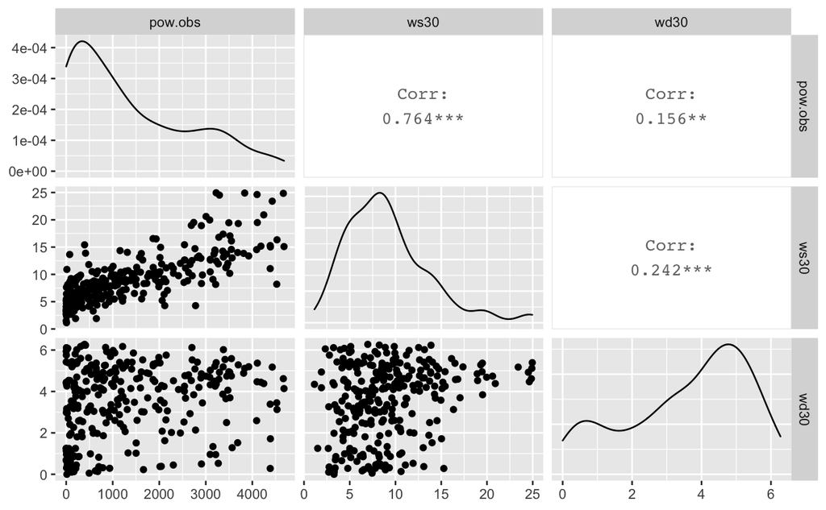

```r
library("ggplot2")                     # Load ggplot2 package
library("GGally")
ggpairs(data[c(0,4:6)])
```

There is a correlation between average daily power production and predicted wind speed. This makes sense as more wind gives more power.

### Normalize the power production, wind speed and wind direction before modelling:

The data is normalized before modelling, as the models require data in the interval [0,1].

```r
data$pow.obs.norm<-(data$pow.obs)/5000
head(data,6)
```

|  | r.day | month | day | pow.obs | ws30 | wd30 | pow.obs.norm |
| --- | --- | --- | --- | --- | --- | --- | --- |
| 1 | 1 | 1 | 1 | 243.0278 | 6.723611 | 4.0343405 | 0.04860556 |
| 2 | 2 | 1 | 2 | 2780.0137 | 4.272603 | 2.1365208 | 0.55600274 |
| 3 | 3 | 1 | 3 | 2118.6164 | 4.272603 | 1.6240318 | 0.42372329 |
| 4 | 4 | 1 | 4 | 1660.8767 | 6.541096 | 0.2269022 | 0.33217534 |
| 5 | 5 | 1 | 5 | 1872.7945 | 9.713699 | 5.3161852 | 0.37455890 |
| 6 | 6 | 1 | 6 | 3212.2603 | 8.161644 | 0.9522963 | 0.64245205 |

# Fitting different distritbutions to the data

A function is created for each distribution that is fitted to the data. The function can then be called using different data sets. The functions returns the MLE for the parameters in the model and the 95 % confidence intervals. The models are compared using AIC.

## Fitting a beta distribution

The likelihood function for the data, can be defined as a sum of the log density functions
$$l(\theta)=\sum_{i=1}^{n}log(p_{\theta}(x_{i}))$$

where $p_{\theta}$ in this case is the beta density function given as:
$$f(x) = \frac{(x-a)^{p-1}(b-x)^{q-1}}{B(p,q) (b-a)^{p+q-1}}
\hspace{.3in} a \le x \le b; p, q > 0$$

where p and q are the shape parameters, a and b are the lower and upper bounds, respectively, of the distribution, and B(p,q) is the beta function. The beta function has the formula
$$B(\alpha,\beta) = \int_{0}^{1} {t^{\alpha-1}(1-t)^{\beta-1}dt}$$
The optimal value of the two shape parameters must be found. This can be done using profile likelihood. Let $(\theta, \delta)$ be the full parameter and $\theta$ the parameter of interest. Given the joint likelihood $L(\theta, \delta)$ the profile likelihood of $\theta$ is
$$L(\theta)=max_{\delta}L(\theta, \delta)$$
Where the maximization is performed at fixed value of $\theta$.

However, we will just do it quickly using the optimizer nlminb.

```r
library(numDeriv)

beta.function = function(dat){
# Define likelihood function:
Beta.likelihood=function(params,dat){ -sum(dbeta(x=dat,shape1=params[1], shape2=params[2], log=TRUE))}
# Find the optimal parameters using nlimnb:
opt=nlminb(c(0.01,0.01),Beta.likelihood, dat=dat)
# Find the Fisher information:
H=hessian(Beta.likelihood,opt$par, dat=dat)
se=sqrt(diag(solve(H)))

CI1=opt$par[1]+c(-1,1)*se[1]*qnorm(0.975)
CI2=opt$par[2]+c(-1,1)*se[2]*qnorm(0.975)

return(list("opt"=opt,"CI1"=CI1, "CI2"=CI2, "se"=se))
}
```

## Fitting a gamma distribution

The density function for a gamma distribution is:
$$f(x) = \frac{(\frac{x-\mu}{\beta})^{\gamma - 1}\exp{(-\frac{x-\mu}
{\beta}})} {\beta\Gamma(\gamma)} \hspace{.2in} x \ge \mu; \gamma,
\beta > 0$$

```r
gamma.function=function(dat){
# Define likelihood function:
Gamma.likelihood=function(params, dat){ -sum(dgamma(x=dat,shape=params[1], rate=params[2], log=TRUE))}

# Find the optimal parameters using nlimnb:
opt=nlminb(c(0.01,0.01),Gamma.likelihood, dat=dat)
# Find the Fisher information:
H=hessian(Gamma.likelihood,opt$par, dat=dat)
se=sqrt(diag(solve(H)))

CI1=opt$par[1]+c(-1,1)*se[1]*qnorm(0.975)
CI2=opt$par[2]+c(-1,1)*se[2]*qnorm(0.975)

return(list("opt"=opt,"CI1"=CI1, "CI2"=CI2, "se"=se))
}
```

## Fitting a log-normal distribution

The density function for a log-normal distribution is:
$$f(x)=\frac{1}{x \sigma \sqrt{2 \pi}} \exp \left(-\frac{(\ln x-\mu)^{2}}{2 \sigma^{2}}\right)$$

```r
log.normal.function=function(dat){
# Define likelihood function:
LogNormal.likelihood=function(params,dat){ -sum(dlnorm(x=dat,meanlog=params[1], sdlog=params[2], log=TRUE))}

# Find the optimal parameters using nlimnb:
opt=nlminb(c(0.01,0.01),LogNormal.likelihood, dat=dat)
# Find the Fisher information:
H=hessian(LogNormal.likelihood,opt$par, dat=dat)
se=sqrt(diag(solve(H)))

CI1=opt$par[1]+c(-1,1)*se[1]*qnorm(0.975)
CI2=opt$par[2]+c(-1,1)*se[2]*qnorm(0.975)

return(list("opt"=opt,"CI1"=CI1, "CI2"=CI2, "se"=se))
}
```

## Fitting a Normal distribution

```r
normal.function=function(dat){
# Define likelihood function:
Normal.likelihood=function(params,dat){ -sum(dnorm(x=dat,mean=params[1], sd=params[2], log=TRUE))}

# Find the optimal parameters using nlimnb:
opt=nlminb(c(0.01,0.01),Normal.likelihood, dat=dat)
# Find the Fisher information:
H=hessian(Normal.likelihood,opt$par, dat=dat)
se=sqrt(diag(solve(H)))

CI1=opt$par[1]+c(-1,1)*se[1]*qnorm(0.975)
CI2=opt$par[2]+c(-1,1)*se[2]*qnorm(0.975)

return(list("opt"=opt,"CI1"=CI1, "CI2"=CI2, "se"=se))
}
```

## Fitting a Vonmieses distribution

```r
Vonmieses.function=function(dat){
# Define likelihood function:
Vonmieses.likelihood=function(params,dat){ -sum(dvonmises(x=dat, mu=params[1], kappa=params[2], log=TRUE))}

# Find the optimal parameters using nlimnb:
opt=nlminb(c(1,1),Vonmieses.likelihood, dat=dat,lower = 0.1, upper = Inf)
# Find the Fisher information:
H=hessian(Vonmieses.likelihood,opt$par, dat=dat)
se=sqrt(diag(solve(H)))

CI1=opt$par[1]+c(-1,1)*se[1]*qnorm(0.975)
CI2=opt$par[2]+c(-1,1)*se[2]*qnorm(0.975)

return(list("opt"=opt,"CI1"=CI1, "CI2"=CI2, "se"=se))
}
```

## Fit transformations

Different transformations will be applied to the power obs data to test if the model performance of the 3 models above can be improved. Before transforming the data the optimal lambda most be found for each transformation. This is done below. A qq-plot is created for each transformation so that it is possible to se how the transformation affects the data.

##### Box Cox

Box Cox transformation
$$Y_{\lambda}=\frac{y^{\lambda}-1}{\lambda}$$

```r
## box-cox transformation
bc.trans <- function(lambda,y){
    y.l <- (y^lambda-1)/lambda

    if(lambda==0){y.l <- log(y)}
    return(y.l)}

## profile likelihood for lambda
lp.lambda <- function(lambda,y){
    n <- length(y)
    y.l <- bc.trans(lambda ,y)
    sigmasq <- 1/n * sum((y.l-mean(y.l))^2)
    -n/2 * log(sigmasq) + (lambda-1)*sum(log(y))}

(opt.lambda.boxcox=optimize(lp.lambda,c(-2,2),y=data$pow.obs.norm,maximum=TRUE))
```

```
$maximum
[1] 0.3467421

$objective
[1] 505.2733
```

```r
par(mfrow=c(1,2))
qqnorm(bc.trans(opt.lambda.boxcox$maximum,data$pow.obs.norm),main="Distribution after boxcox transformation")
qqline(bc.trans(opt.lambda.boxcox$maximum,data$pow.obs.norm))
```

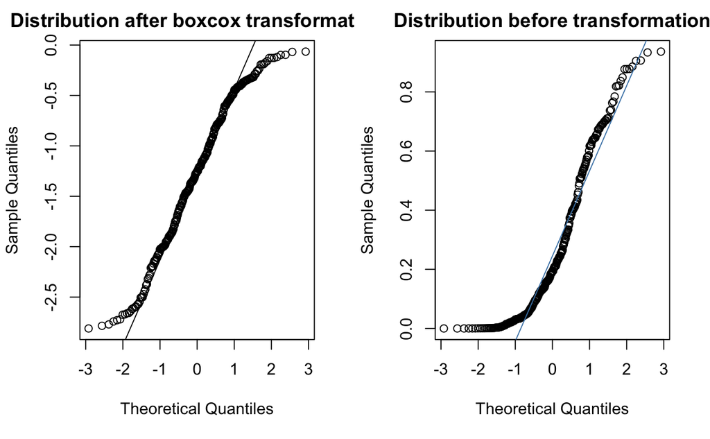

```r
qqnorm(data$pow.obs.norm, pch = 1, frame = TRUE, main="Distribution before transformation")
qqline(data$pow.obs.norm, col = "steelblue")
```

## Transformation 1:

Now to the first transformation mentioned in the assigment:
$$Y^{(\lambda)}=\frac{1}{\lambda}log(\frac{y^{\lambda}}{y^{\lambda}-1}), \quad \lambda>0$$
We will use change of variables to find the profile likelihoods. The change of variables is defined as:
$$Y=g(X)$$
$$f_{X}(x)=f_{Y}(y)\cdot|\frac{dg}{dx}|$$
This is applied to transformation 1:
$$\frac{dY^{\lambda}}{dY}=\frac{d}{dY}\frac{1}{\lambda}log(\frac{y^{\lambda}}{y^{\lambda}-1})=\frac{-1}{(y\cdot(-1 + y^{\lambda})}$$
The profile likelihood is then found by multiplying the above with a part of the normal distribution:
$$lp(y)=\frac{-n}{2} \cdot log(\sigma^{2}) + \sum\frac{-1}{(y\cdot(-1 + y^{\lambda}))}$$

```r
trans1 <- function(lambda,y){
    y.l <- 1/lambda*log((y^lambda)/(1-y^lambda))
    return(y.l)}

## profile likelihood for lambda
lp.lambda1 <- function(lambda,y){
    n <- length(y)
    y.l <- trans1(lambda ,y)
    sigmasq <- 1/n * sum((y.l-mean(y.l))^2)
    -n/2 * log(sigmasq) + sum(log(abs(-1/(y*(-1 + y^lambda)))))}

(opt.lambda.trans1=optimize(lp.lambda1,c(0.000001,70),y=data$pow.obs.norm, maximum=TRUE))
```

```
$maximum
[1] 0.2620846

$objective
[1] 531.0011
```

```r
par(mfrow=c(1,2))
qqnorm((trans1(opt.lambda.trans1$maximum,data$pow.obs.norm)),main="Distribution after transformation 1")
qqline((trans1(opt.lambda.trans1$maximum,data$pow.obs.norm)))
```

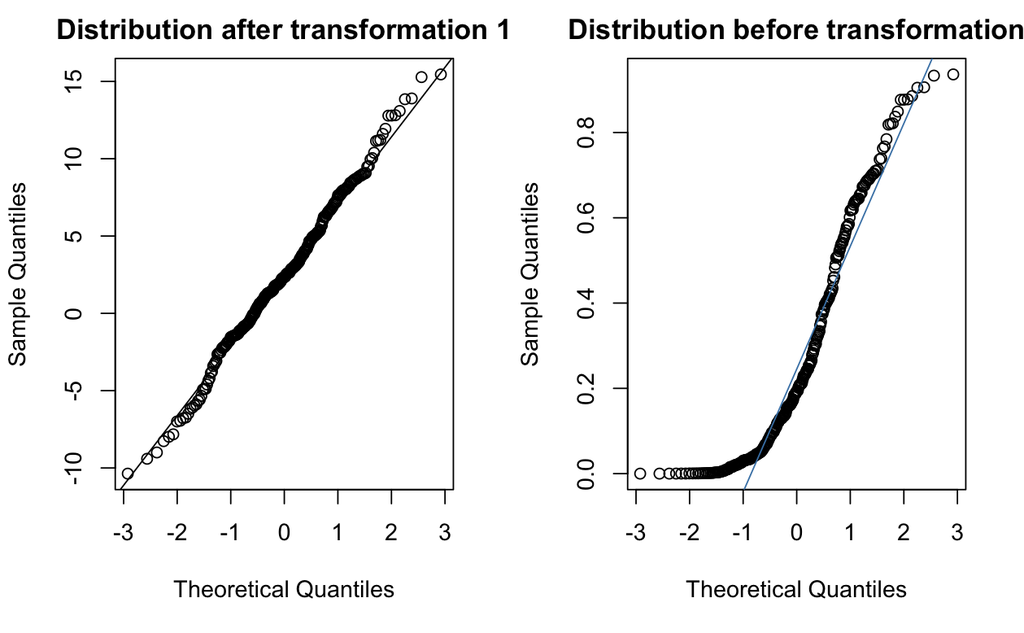

```r
qqnorm(data$pow.obs.norm, pch = 1, frame = TRUE, main="Distribution before transformation")
qqline(data$pow.obs.norm, col = "steelblue")
```

##### Transformation 2

The second transformation mentioned in the assigment:
$$Y^{(\lambda)}=2 \cdot log(\frac{y^{\lambda}}{(1-y)^{1-\lambda}}), \quad \lambda \in (0,1)$$
The approach for finding the profile likelihood function is the same as for transformation 1.

We will use change of variables to find the profile likelihoods (slide 25 lecture 5)

```r
trans2 <- function(lambda,y){
    y.l <- 2*log((y^lambda)/(1-y)^(1-lambda))
    return(y.l)}

## profile likelihood for lambda
lp.lambda2 <- function(lambda,y){
    n <- length(y)
    y.l <- trans2(lambda ,y)
    sigmasq <- 1/n * sum((y.l-mean(y.l))^2)
    -n/2 * log(sigmasq) + sum(log(abs(((4*lambda - 2)*y - 2*lambda)/(y*(-1 + y)))))}

(opt.lambda.trans2=optimize(lp.lambda2,c(0.000001,1),y=data$pow.obs.norm, maximum=TRUE))
```

```
$maximum
[1] 0.2523298

$objective
[1] 527.0707
```

```r
par(mfrow=c(1,2))
qqnorm((trans2(opt.lambda.trans2$maximum,data$pow.obs.norm)),main="Distribution after transformation 2")
qqline((trans2(opt.lambda.trans2$maximum,data$pow.obs.norm)))
```

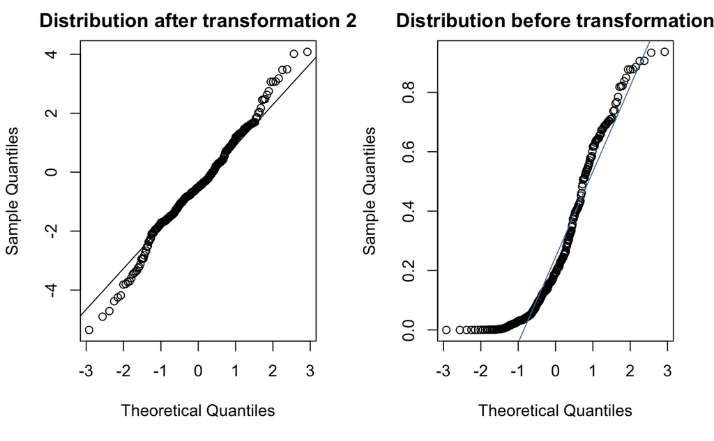

```r
qqnorm(data$pow.obs.norm, pch = 1, frame = TRUE, main="Distribution before transformation")
qqline(data$pow.obs.norm, col = "steelblue")
```

## Fitting all distributions to the data:

The models will be compared using AIC. AIC is calculated using the formula:
$$AIC=2k-2ln(\hat{L})$$
where L is the maximum value for the likelihood function for the model. (The likelihood functions defined are negative log likelihoods, so remember to insert (-L)!) j

```r
AIC=function(k,L){2*k-2*L}
```

The table below shows the AIC for all models created. The lower the AIC the better.

[output not shown]

[output cut: 1197 more lines]

[output not shown]

| Data | AIC Beta Distribution | AIC Gamma Distribution | AIC Log-Normal Distribution | AIC Normal Distribution | AIC Von Mises |
| --- | --- | --- | --- | --- | --- |
| Power Obs | -239 | -191 | -48 | 36 | NA |
| Wind Speed | NA | 1635 | 1643 | 1694 | 1061 |
| Wind direction | NA | 1251 | 1440 | 1136 | 1066 |
| Boxcox Power Obs | NA | NA | NA | 624 | NA |
| Transformation 1 Power Obs | NA | NA | NA | 1712 | NA |
| Transformation 2 Power Obs | NA | NA | NA | 1084 | NA |

The NA values indicates, that the model have not been tested on the corresponding data set. The overall best model for Power Obs is the beta model, whereas the best model for wind speed and wind direction is Von Mises.

The table below shows the MLE coefficients for the parameters for all models created using the beta distribution. The 95% confidence interval is included for each parameter.

| Beta Distribution for | Optimal Shape 1 | Optimal Shape 2 | Lower CI Shape 1 | Upper CI Shape 1 | Lower CI Shape 2 | Upper CI Shape 2 |
| --- | --- | --- | --- | --- | --- | --- |
| Power Obs | 0.56 | 1.49 | 0.48 | 0.63 | 1.24 | 1.75 |

The table below shows the MLE coefficients for the parameters for all models created using the gamma distribution. The 95% confidence interval is included for each parameter.

[output not shown]

| Gamma Distribution for | Optimal Shape | Optimal Rate | Lower CI Shape | Upper CI Shape | Lower CI Rate | Upper CI Rate |
| --- | --- | --- | --- | --- | --- | --- |
| Power Obs | 0.69 | 2.51 | 0.6 | 0.79 | 2.01 | 3 |
| Wind Speed | 4.16 | 0.46 | 3.5 | 4.81 | 0.38 | 0.53 |
| Wind direction | 2.01 | 0.56 | 1.7 | 2.31 | 0.46 | 0.65 |

The table below shows the MLE coefficients for the parameters for all models created using the log normal distribution. The 95% confidence interval is included for each parameter.

| Log Normal Distribution for | Optimal Mean Log | Optimal Sd Log | Lower CI Mean Log | Upper CI Mean Log | Lower CI Sd Log | Upper CI Sd Log |
| --- | --- | --- | --- | --- | --- | --- |
| Power Obs | -2.16 | 1.92 | -2.38 | -1.94 | 1.76 | 2.07 |
| Wind Speed | 2.08 | 0.52 | 2.02 | 2.14 | 0.48 | 0.56 |
| Wind direction | 1.01 | 1.06 | 0.89 | 1.14 | 0.98 | 1.15 |

The table below shows the MLE coefficients for the parameters for all models created using the normal distribution. The 95% confidence interval is included for each parameter.

[output not shown]

| Normal Distribution for | Optimal Mean | Optimal Sd | Lower CI Mean | Upper CI Mean | Lower CI Sd | Upper CI Sd |
| --- | --- | --- | --- | --- | --- | --- |
| Power Obs | 0.28 | 0.26 | 0.25 | 0.31 | 0.23 | 0.28 |
| Wind Speed | 9.11 | 4.55 | 8.59 | 9.64 | 4.18 | 4.92 |
| Wind direction | 3.6 | 1.73 | 3.4 | 3.8 | 1.59 | 1.87 |
| Boxcox | -1.29 | 0.71 | -1.37 | -1.2 | 0.65 | 0.77 |
| Trans 1 | 2.54 | 4.7 | 1.99 | 3.08 | 4.31 | 5.08 |
| Trans 2 | -0.45 | 1.58 | -0.64 | -0.27 | 1.45 | 1.71 |

The table below shows the MLE coefficients for the parameters for all models created using the Von Mises distribution. The 95% confidence interval is included for each parameter.

[output not shown]

[output cut: 3684 more lines]

[output not shown]

| Von Mises Distribution for | Optimal Mean | Optimal Kappa | Lower CI Mean | Upper CI Mean | Lower CI Kappa | Upper CI Kappa |
| --- | --- | --- | --- | --- | --- | --- |
| Wind Speed | 2.57 | 0.1 | 0.86 | 4.29 | -0.06 | 0.26 |
| Wind direction | 0.1 | 0.1 | NaN | NaN | 0.08 | 0.12 |

## Plotting the best models:

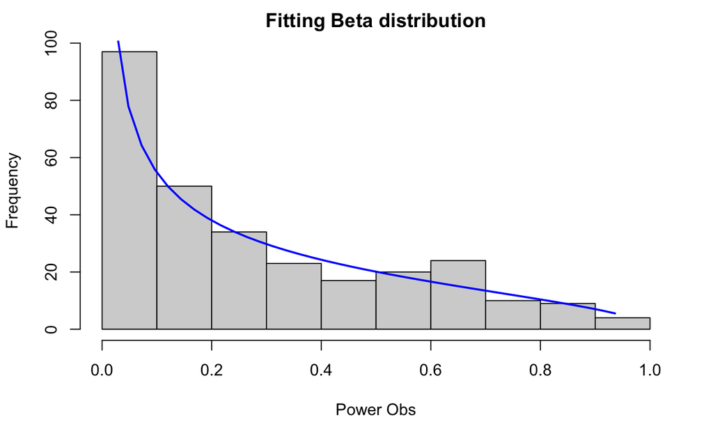

```r
x <-data$pow.obs.norm
h<-hist(x, xlab="Power Obs",main="Fitting Beta distribution")
xfit<-seq(min(x),max(x),length=40)
yfit<-dbeta(xfit,beta.function(data$pow.obs.norm)$opt$par[1],beta.function(data$pow.obs.norm)$opt$par[2])
yfit <- yfit*diff(h$mids[1:2])*length(x)
lines(xfit, yfit, col="blue", lwd=2)
```

```r
x <- circular(data$wd30)
h<-hist(x, xlab="Wind Speed",
   main="Von Mises distribution")
```

[output not shown]

### For wind direction use vonmieses distribution - do the likelihood based interval use uniroot first week solution.

### Reparameterisering - Hans Martins note!

```r
gamma.function.rep=function(dat){
# Define likelihood function:
Gamma.likelihood=function(params, dat){ -sum(dgamma(x=dat,shape=params[1]*params[2], rate=params[2], log=TRUE))}

# Find the optimal parameters using nlimnb:
opt=nlminb(c(0.01,0.01),Gamma.likelihood, dat=dat)
# Find the Fisher information:
H=hessian(Gamma.likelihood,opt$par, dat=dat)
se=sqrt(diag(solve(H)))

CI1=opt$par[1]+c(-1,1)*se[1]*qnorm(0.975)
CI2=opt$par[2]+c(-1,1)*se[2]*qnorm(0.975)

return(list("opt"=opt,"CI1"=CI1, "CI2"=CI2, "se"=se))
}
```

```r
gamma.function.rep(data$pow.obs.norm)
```

```
$opt
$opt$par
[1] 0.2762392 2.5073938

$opt$objective
[1] -97.38174

$opt$convergence
[1] 0

$opt$iterations
[1] 13

$opt$evaluations
function gradient
      16       32

$opt$message
[1] "relative convergence (4)"


$CI1
[1] 0.2379052 0.3145731

$CI2
[1] 2.014854 2.999934

$se
[1] 0.01955848 0.25130047
```

$\mu$ is 0.276 and is with 95% certainty in the confidence interval [0.2379052, 0.3145731]

```r
beta.function.rep = function(dat){
# Define likelihood function:
Beta.likelihood=function(params,dat){ -sum(dbeta(x=dat,shape1=-(params[1]*params[2])/(params[1]-1), shape2=params[2], log=TRUE))}
# Find the optimal parameters using nlimnb:
opt=nlminb(c(0.01,0.01),Beta.likelihood, dat=dat)
# Find the Fisher information:
H=hessian(Beta.likelihood,opt$par, dat=dat)
se=sqrt(diag(solve(H)))

CI1=opt$par[1]+c(-1,1)*se[1]*qnorm(0.975)
CI2=opt$par[2]+c(-1,1)*se[2]*qnorm(0.975)

return(list("opt"=opt,"CI1"=CI1, "CI2"=CI2, "se"=se))
}
```

```r
beta.function.rep(data$pow.obs.norm)
```

```
$opt
$opt$par
[1] 0.2718999 1.4918278

$opt$objective
[1] -121.6618

$opt$convergence
[1] 0

$opt$iterations
[1] 9

$opt$evaluations
function gradient
      11       24

$opt$message
[1] "relative convergence (4)"


$CI1
[1] 0.2437152 0.3000847

$CI2
[1] 1.235853 1.747803

$se
[1] 0.01438023 0.13060188
```

$\mu$ is 0.272 and is with 95% certainty in the confidence interval [0.2437152, 0.3000847]